# Procesy stochastyczne - lab04, Tomasz Kozioł

Tomasz Kozioł

2023-04-28

#### DANE

Dane sa procesy losowe (X_t) oraz (Y_t), dla ktorych $X(1)=Y(1)=1$, $X(2)=Y(2)=-0,5$, $X(3)=Y(3)=1$ oraz, dla $t>3$:

$X(t) = 0.3*X(t-1) - 0.7*X(t-2) + 0.1*X(t-3) + A(t),$

$Y(t) = A(t) - 0.4*A(t-1) + 0.2*A(t-2) + 0.1*A(t-3),$

$Z(t) = A(t),$

$Q(t) = X(t) + Y(t)$

gdzie $A(t)$ jest gaussowskim szumem bialym o sredniej $0$ oraz odchyleniu standardowym rownym $1$.

#### D.1

Zasymuluj po 4 realizacje kazdego procesu oraz, dla kazdego procesu osobno, przedstaw je na jednym wykresie zaznaczajac kazda realizacje innym kolorem.

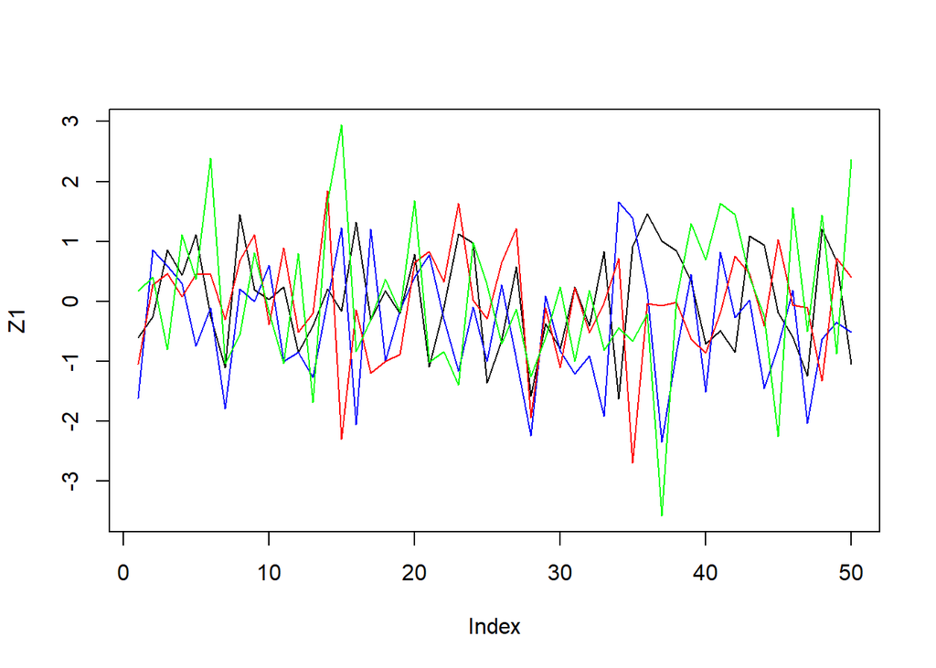

```r
N <- 50
A1 <- rnorm(N,0,1)
A2 <- rnorm(N,0,1)
A3 <- rnorm(N,0,1)
A4 <- rnorm(N,0,1)

Z1 <- A1
Z2 <- A2
Z3 <- A3
Z4 <- A4

plot(Z1, t="l", ylim=c(min(c(Z1,Z2,Z3,Z4)),max(c(Z1,Z2,Z3,Z4))))
lines(Z2, col="blue")
lines(Z3, col="red")
lines(Z4, col="green")
```

```r
Xt <- function(t,A){
    if (t==1) return(1)
    if (t==2) return(-0.5)
    if (t==3) return(1)
    else return(0.3*Xt(t-1,A)-0.7*Xt(t-2,A)+0.1*Xt(t-3,A)+A[t])
}

Xt(1,A1)
```

```
## [1] 1
```

```r
Xt(2,A1)
```

```
## [1] -0.5
```

```r
Xt(3,A1)
```

```
## [1] 1
```

```r
Xt(5,A1)
```

```
## [1] 0.7259352
```

```r
Xt(10,A1)
```

```
## [1] -0.6725735
```

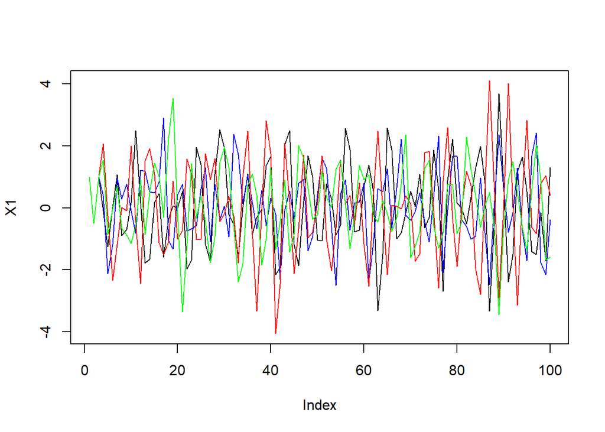

```r
Xt <- function(N)
{
  A1 <- rnorm(N, 0, 1)
  X1 <- numeric(N)
  X1[1:3] <- c(1, -1 / 2, 1)
  for (t in 4:N)
  {
    X1[t] <- 0.3 * X1[t - 1] - 0.7 * X1[t - 2] + 0.1 * X1[t - 3] + A1[t]
  }
  return(X1)
}

X1 <- Xt(100)
X2 <- Xt(100)
X3 <- Xt(100)
X4 <- Xt(100)

plot(X1, t = "l", ylim = c(min(c(X1, X2, X3, X4)), max(c(X1, X2, X3, X4))))
lines(X2, col = "blue")
lines(X3, col = "red")
lines(X4, col = "green")
```

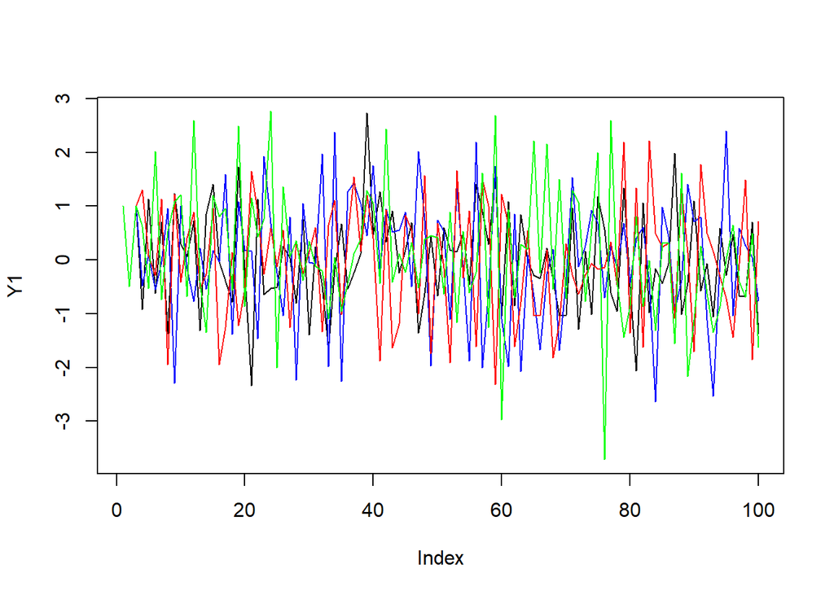

```r
Yt <- function(N)
{
  A1 <- rnorm(N, 0, 1)
  Y1 <- numeric(N)
  Y1[1:3] <- c(1, -1 / 2, 1)
  for (t in 4:N)
  {
    Y1[t] <- A1[t] - 0.4 * A1[t - 1] + 0.2 * A1[t - 2] + 0.1 * A1[t - 3]
  }
  return(Y1)
}

Y1 <- Yt(100)
Y2 <- Yt(100)
Y3 <- Yt(100)
Y4 <- Yt(100)

plot(Y1, t = "l", ylim = c(min(c(Y1, Y2, Y3, Y4)), max(c(Y1, Y2, Y3, Y4))))
lines(Y2, col = "blue")
lines(Y3, col = "red")
lines(Y4, col = "green")
```

```r
Qt <- function (N) {
  return(Xt(N) + Yt(N))
}
Qt(5)
```

```
## [1]  2.0000000 -1.0000000  2.0000000 -1.6426477 -0.5910472
```

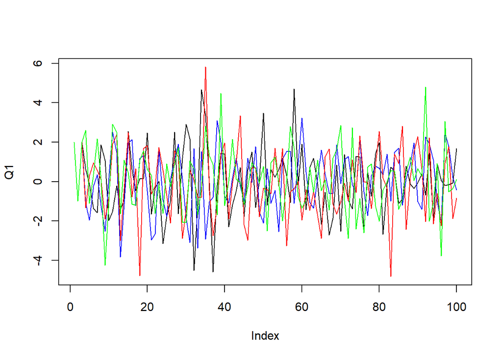

```r
Q1 <- Qt(100)
Q2 <- Qt(100)
Q3 <- Qt(100)
Q4 <- Qt(100)

plot(Q1, t = "l", ylim = c(min(c(Q1, Q2, Q3, Q4)), max(c(Q1, Q2, Q3, Q4))))
lines(Q2, col = "blue")
lines(Q3, col = "red")
lines(Q4, col = "green")
```

#### D.2

Tytul strony zawiera 4 modele, ktore modele opisuja procesy $X(t)$, $Y(t)$, $Z(t)$, $Q(t)$. Ocen rzedy modeli na podstawie wzorow na ich elementy.

Odpowiedzi:

1. X to realizacja modelu autoregresji (AR), rząd modelu = 3
2. Y to realizacja modelu sredniej ruchomej (MA), rząd modelu = 3
3. Z to szum bialy
4. Q to model ARMA, rząd modelu(3,3)

#### D.3

Jezeli zalozymy, ze wybrana trajektoria kazdego z procesow jest realizacja modelu autoregresji, to ktorego rzedu bedzie to model?

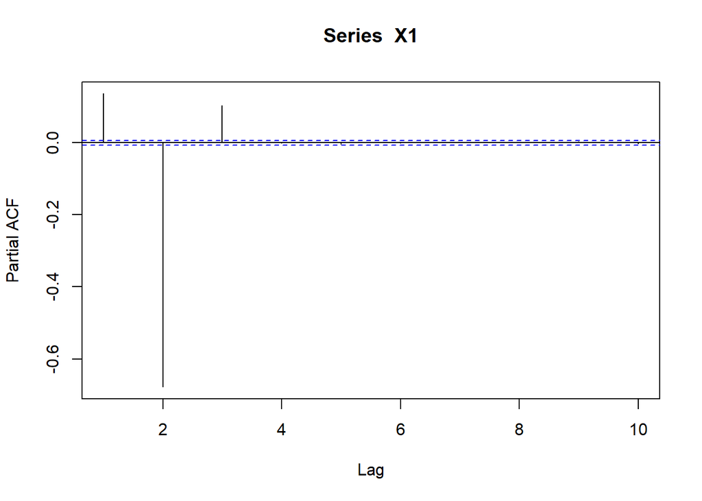

```r
X1 <- Xt(10^5)
pacf(X1, lag.max=10)
```

X1 jest realizacja modelu autoregresji rzedu 3 AR(3)

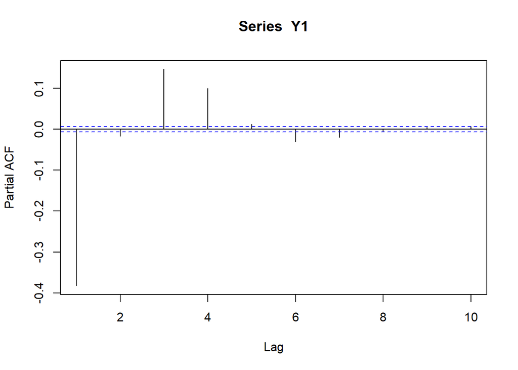

```r
Y1 <- Yt(10^5)
pacf(Y1, lag.max=10)
```

Y1 jest realizacja modelu autoregresji rzedu 7

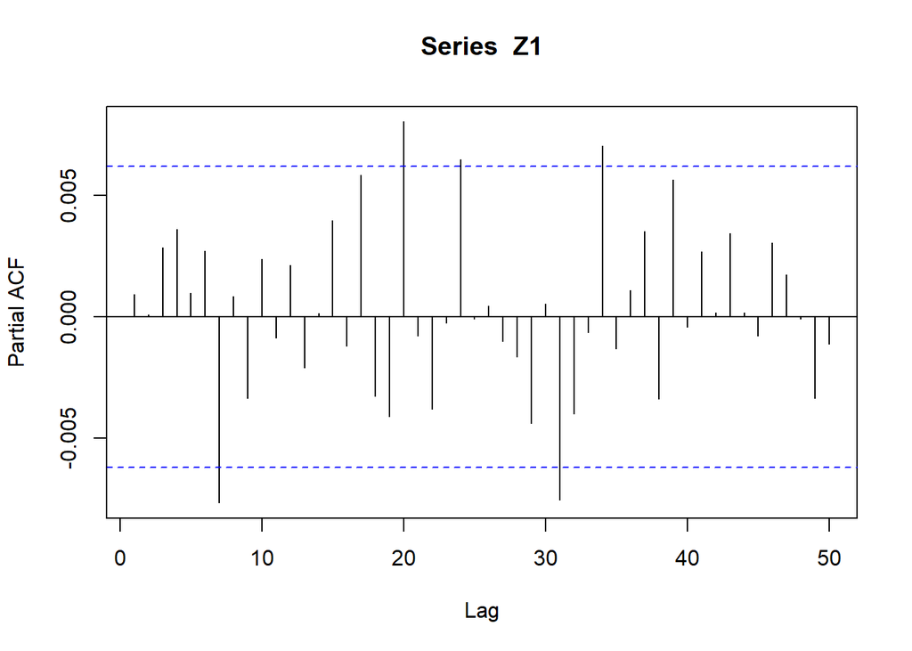

```r
Z1 <- rnorm(10^5,0,1)
pacf(Z1)
```

Z1 jest realizacja modelu autoregresji rzedu 0

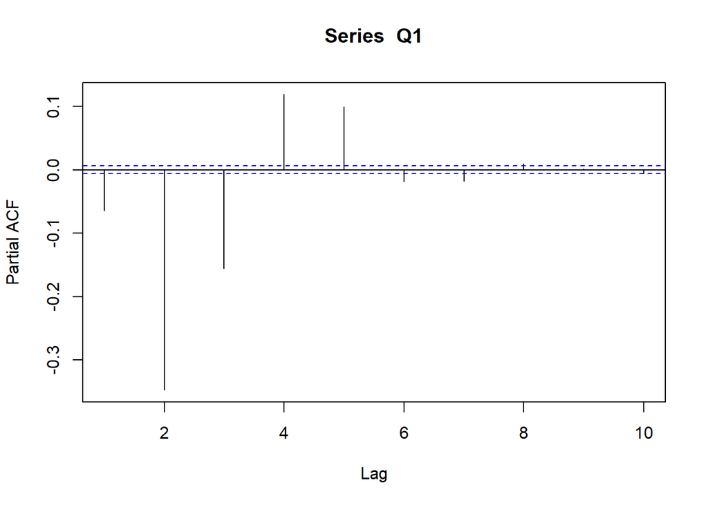

```r
Q1 <- Qt(10^5)
pacf(Q1, lag.max=10)
```

Q1 prawdopodobnie jest realizacja modelu autoregresji rzedu 7 lub rzedu 10

#### D.4

Jezeli zalozymy, ze wybrana trajektoria kazdego z procesow jest realizacja modelu ruchomej sredniej, to ktorego rzedu bedzie to model?

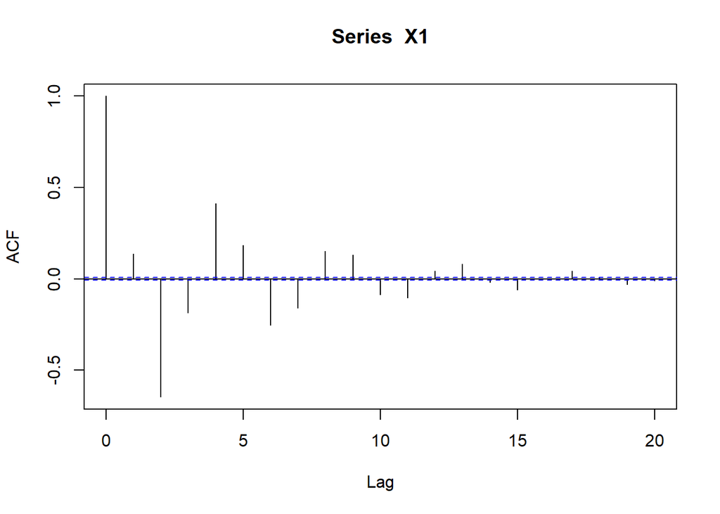

```r
acf(X1, lag.max=20)
```

X1 jest realizacja ruchomej sredniej rzedu 19, MA(19)

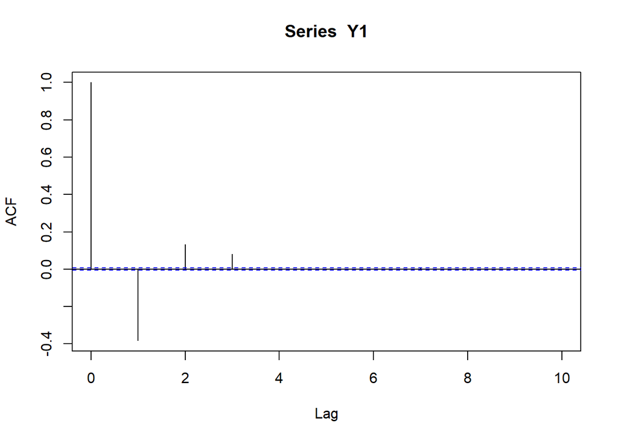

```r
acf(Y1, lag.max=10)
```

Y1 jest realizacja ruchomej sredniej rzedu 3, MA(3)

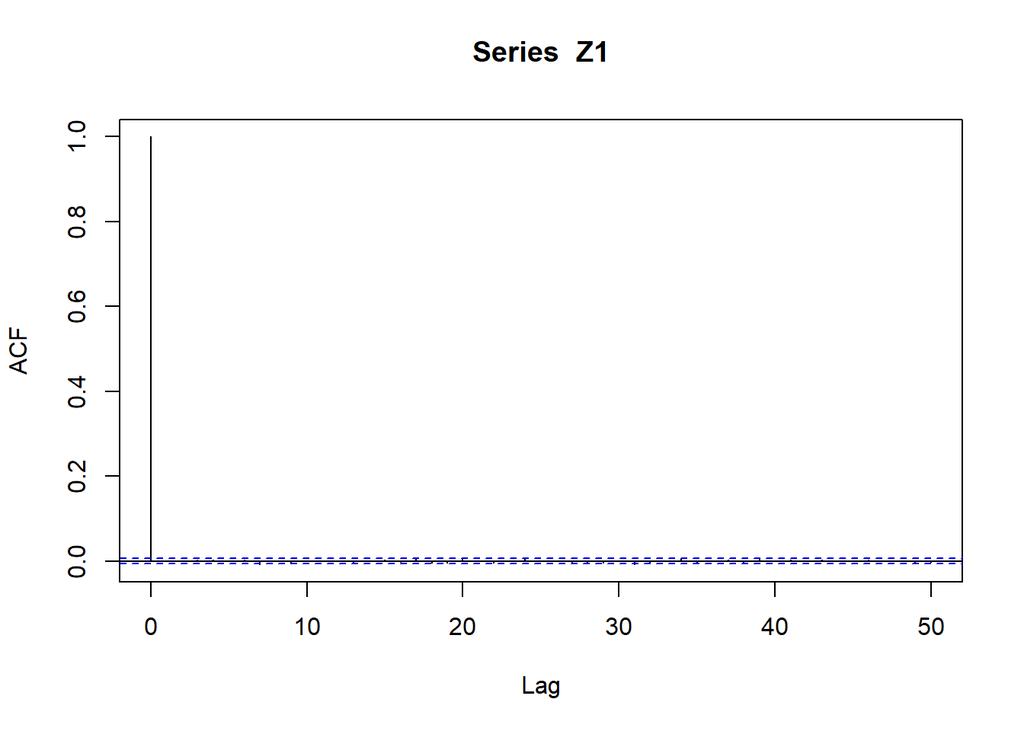

```r
acf(Z1)
```

Z1 to szum bialy, model rzedu 0

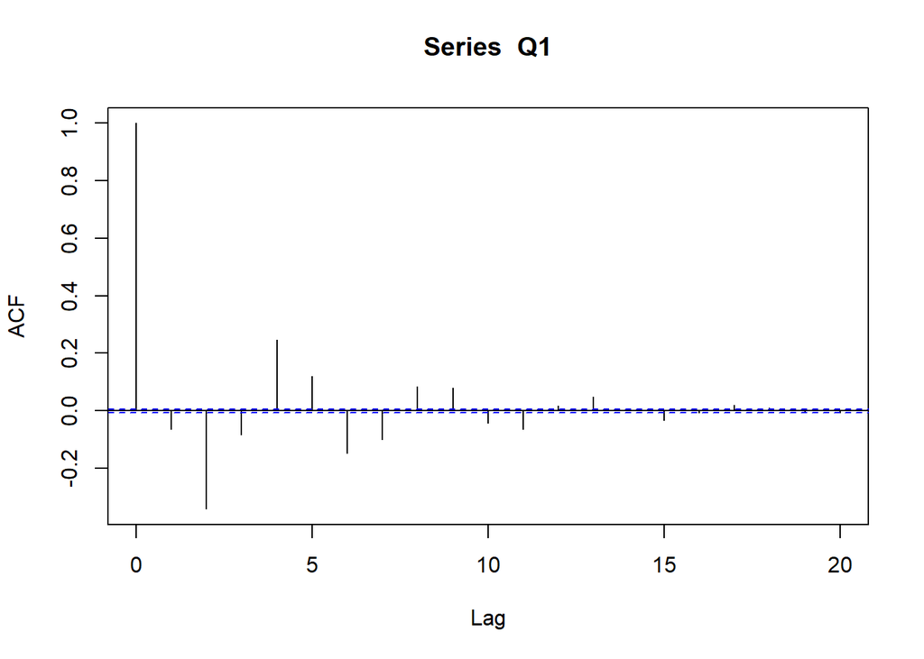

```r
acf(Q1, lag.max=20)
```

Q1 jest realizacja ruchomej sredniej rzedu 19, MA(19)

#### D.5

Korzystajac z narzadzi dostepnych w R i analizujac wylacznie realizacje kazdego z procesow, wyznacz typy i rzedy modeli (auto.arima?)

```r
library("forecast")
auto.arima(X1)
```

```
## Series: X1
## ARIMA(3,0,0) with zero mean
##
## Coefficients:
##          ar1      ar2     ar3
##       0.2984  -0.7013  0.1034
## s.e.  0.0031   0.0024  0.0031
##
## sigma^2 = 0.9881:  log likelihood = -141293.5
## AIC=282595   AICc=282595.1   BIC=282633.1
```

```r
auto.arima(Y1)
```

```
## Series: Y1
## ARIMA(3,0,2) with zero mean
##
## Coefficients:
##          ar1      ar2     ar3      ma1     ma2
##       0.2379  -0.0669  0.0238  -0.6405  0.3617
## s.e.  0.0166   0.0127  0.0077   0.0164  0.0155
##
## sigma^2 = 1.003:  log likelihood = -142055.1
## AIC=284122.2   AICc=284122.2   BIC=284179.3
```

```r
auto.arima(Z1)
```

```
## Series: Z1
## ARIMA(0,0,0) with zero mean
##
## sigma^2 = 0.9975:  log likelihood = -141769
## AIC=283540.1   AICc=283540.1   BIC=283549.6
```

```r
auto.arima(Q1)
```

```
## Series: Q1
## ARIMA(5,0,3) with non-zero mean
##
## Coefficients:
##          ar1      ar2     ar3     ar4     ar5      ma1     ma2      ma3
##       0.0875  -0.5040  0.0146  0.0868  0.0668  -0.2189  0.2335  -0.0873
## s.e.  0.1034   0.0246  0.0619  0.0101  0.0096   0.1034  0.0353   0.0361
##          mean
##       -0.0042
## s.e.   0.0038
##
## sigma^2 = 2.6:  log likelihood = -189667.3
## AIC=379354.5   AICc=379354.5   BIC=379449.7
```

#### D.6

Zalozmy, ze realizacje procesu $X(t)$ opisuje model autoregresji, z rzedem wyznaczonym w zadaniu D.3. Wyznacz wspolczynniki modelu. (ar())

```r
ar(X1, order.max = 3)
```

```
##
## Call:
## ar(x = X1, order.max = 3)
##
## Coefficients:
##       1        2        3
##  0.2984  -0.7013   0.1034
##
## Order selected 3  sigma^2 estimated as  0.9881
```

#### D.7

Zalozmymy, ze realizacje procesu $Y(t)$ opisuje model ruchomej sredniej, z rzedem wyznaczonym w zadaniu D.4. Wyznacz wspolczynniki modelu. (Arima())

```r
Arima(Y1, order = c(0,0,3))
```

```
## Series: Y1
## ARIMA(0,0,3) with non-zero mean
##
## Coefficients:
##           ma1     ma2     ma3    mean
##       -0.4026  0.1992  0.0978  0.0003
## s.e.   0.0031  0.0033  0.0031  0.0028
##
## sigma^2 = 1.003:  log likelihood = -142055.6
## AIC=284121.2   AICc=284121.2   BIC=284168.8
```

#### D.8

Bazujac na typie modelu wyznaczonym z zadaniu D.5, wyznacz wspolczynniki modelu dla realizacji procesu Q(t). Dlaczego wartosci wyznaczonych wspolczynnikow sa znaczaco rozne od tych, ktore wydaje sie, ze wynikaja z tresci ”śDANYCH”ť? Stworz proces ARMA(3,3) wraz z realizacja, ktorego wspolczynniki beda wynosily
$$(\{0.3, - 0.7, 0.1\},\{- 0.4,
0.2,0.1\})$$

```r
Arima(Q1, order = c(3,0,3))
```

```
## Series: Q1
## ARIMA(3,0,3) with non-zero mean
##
## Coefficients:
##           ar1      ar2      ar3      ma1     ma2     ma3     mean
##       -0.1163  -0.6373  -0.2332  -0.0151  0.3362  0.0785  -0.0041
## s.e.   0.0395   0.0127   0.0289   0.0397  0.0175  0.0197   0.0036
##
## sigma^2 = 2.603:  log likelihood = -189719.4
## AIC=379454.8   AICc=379454.8   BIC=379530.9
```

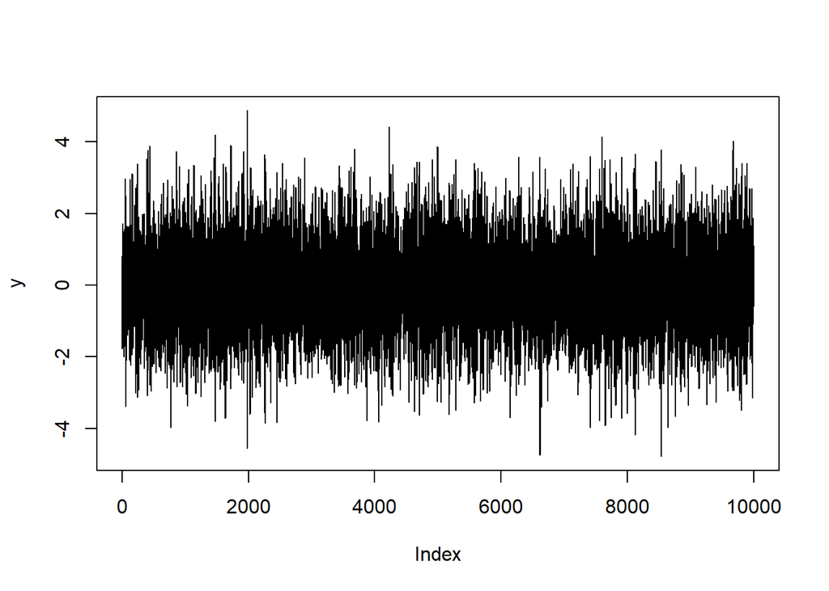

```r
set.seed(0.997)
N <- 10000
x <- rnorm(N)
y <- numeric(N)

a <- c(0.3,-0.7, 0.1)
b <- c(-0.4, 0.2, 0.1)

for (i in 4:N) {
  y[i] <-
    a[1] * y[i - 1] + a[2] * y[i - 2] + a[3] * y[i - 3] + b[1] * x[i - 1] + b[2] *
    x[i - 2] + b[3] * x[i - 3] + x[i]
}

plot(y, type = "l")
```